# Laboratorio 2.1: Clasificación

Hernán Sarmiento, Andrés Abeliuk, Alison Fernandez, Cinthia Sánchez, Johnny Godoy, Gabriel Ramos, Cristian Llull y Matías Rojas

Octubre 2021

## ============= Declaración de compromiso ético =============

Nosotros, *Ignacio Díaz y Millaray Valdivia*, declaramos que realizamos de manera grupal los pasos de la presente actividad. También declaramos no incurrir en copia, ni compartir nuestras respuestas con otras personas ni con otros grupos. Por lo que, ratificamos que las respuestas son de nuestra propia confección y reflejan nuestro propio conocimiento.

# Instrucciones

1. Trabajen en equipos de dos personas. Salvo excepciones, no se corregirá entregas con menos de dos integrantes.
2. Modifique este archivo `.ipynb` agregando sus respuestas donde corresponda.
3. El formato de entrega para esta actividad es un archivo html. **Genere un archivo HTML** usando jupyter (ver tutorial 2) y súbalo a U-Cursos. Basta con que uno de los integrantes haga la entrega. Si ambos hacen una entrega en U-Cursos, se revisará cualquiera de éstas.

# Estructura del laboratorio

Este laboratorio está conformado por preguntas teóricas de temas vistos en clases y preguntas prácticas (donde se requiere completar código) intercaladas con preguntas de interpretación de resultados y análisis. La parte práctica se divide en:

1. Explorar los datos.
2. Entrenar un clasificador de 3 maneras:
   - Entrenando/Testeando con los mismos datos,
   - Dividiendo el dataset en una parte para entrenar y otra para testear, y
   - Usando cross-validation.

# Teoría

#### 2. El mismo consultor siempre usa la misma métrica para evaluar un modelo: accuracy. Comente la estrategia del consultor y proponga una estrategia alternativa.

**Respuesta:** Accuracy es una métrica que tiene sus desventajas, por ejemplo, ante un dataset con clases muy desbalanceadas, en la predicción puede predominar la clase que más abunda. Proponemos que la elección de la métrica sea enfocada en las necesidades de la clasificación. Es importante determinar en qué es más importante no fallar, en un falso negativo o un falso positivo, por ejemplo. Proponer una métrica que considere el trade off entre Precisition y Recall como F-measure o ROC en general es una buena idea, mientras se ponga el enfoque en las características del problema. Se recomienda mucho usar la matriz de costos ya que los pesos que uno debe ingresar permiten evaluar con respecto a las necesidades del problema.

# Parte 1: Explorar los datos

Usaremos el **Wine Dataset**, que viene en **scikit-learn**. Ejecutaremos la siguiente línea de código para importar la librería que nos permitirá cargarlo.

```python
from sklearn.datasets import load_wine
```

## Pregunta 1.1

Cargue los datos e indique lo siguiente:

- Tamaño del dataset (cantidad de instancias y atributos).
- ¿Cuántas clases hay y cuáles son sus nombres?
- ¿Cuántas instancias hay en cada clase?

Indique en cada caso cómo obtuvo la respuesta, es decir, adjunte código.

```python
import pandas as pd
import numpy as np

#cargar el dataset
wine = load_wine()

# tamaño del dataset
print("- Número de columnas: " + str(len(wine.data[0])))
print("- Número de filas: " + str(len(wine.data)))

# número de clases
print("- Número de clases: " + str(len(wine.target_names)))

# nombres de las clases
print("- Nombre de los atributos: ")
print(wine.feature_names)

# número de instancias que hay en una clase
(unique, counts) = np.unique(wine.target, return_counts=True)
for n_clase in unique:
    print("- Número de instancias clase " + str(n_clase) + ": " + str(counts[n_clase]))
```

```
- Número de columnas: 13
- Número de filas: 178
- Número de clases: 3
- Nombre de los atributos:
['alcohol', 'malic_acid', 'ash', 'alcalinity_of_ash', 'magnesium', 'total_phenols', 'flavanoids', 'nonflavanoid_phenols', 'proanthocyanins', 'color_intensity', 'hue', 'od280/od315_of_diluted_wines', 'proline']
- Número de instancias clase 0: 59
- Número de instancias clase 1: 71
- Número de instancias clase 2: 48
```

```python
# También podemos ver esta información en la descripción
print(wine.DESCR)
```

```
.. _wine_dataset:

Wine recognition dataset
------------------------

**Data Set Characteristics:**

    :Number of Instances: 178 (50 in each of three classes)
    :Number of Attributes: 13 numeric, predictive attributes and the class
    :Attribute Information:
 		- Alcohol
 		- Malic acid
 		- Ash
		- Alcalinity of ash
 		- Magnesium
		- Total phenols
 		- Flavanoids
 		- Nonflavanoid phenols
 		- Proanthocyanins
		- Color intensity
 		- Hue
 		- OD280/OD315 of diluted wines
 		- Proline

    - class:
            - class_0
            - class_1
            - class_2

    :Summary Statistics:

    ============================= ==== ===== ======= =====
                                   Min   Max   Mean     SD
    ============================= ==== ===== ======= =====
    Alcohol:                      11.0  14.8    13.0   0.8
    Malic Acid:                   0.74  5.80    2.34  1.12
    Ash:                          1.36  3.23    2.36  0.27
    Alcalinity of Ash:            10.6  30.0    19.5   3.3
    Magnesium:                    70.0 162.0    99.7  14.3
    Total Phenols:                0.98  3.88    2.29  0.63
```

[output cut: 40 more lines]

```
  Tech. Rep. no. 92-02, (1992), Dept. of Computer Science and Dept. of
  Mathematics and Statistics, James Cook University of North Queensland.
  (Also submitted to Technometrics).

  The data was used with many others for comparing various
  classifiers. The classes are separable, though only RDA
  has achieved 100% correct classification.
  (RDA : 100%, QDA 99.4%, LDA 98.9%, 1NN 96.1% (z-transformed data))
  (All results using the leave-one-out technique)

  (2) S. Aeberhard, D. Coomans and O. de Vel,
  "THE CLASSIFICATION PERFORMANCE OF RDA"
  Tech. Rep. no. 92-01, (1992), Dept. of Computer Science and Dept. of
  Mathematics and Statistics, James Cook University of North Queensland.
  (Also submitted to Journal of Chemometrics).
```

## Pregunta 1.2

Explique:

- ¿Qué hacen las siguientes líneas de código?
- ¿Qué nos muestra este gráfico?
- ¿Cuáles son las principales observaciones que puede obtener sobre los datos a partir de los gráficos?

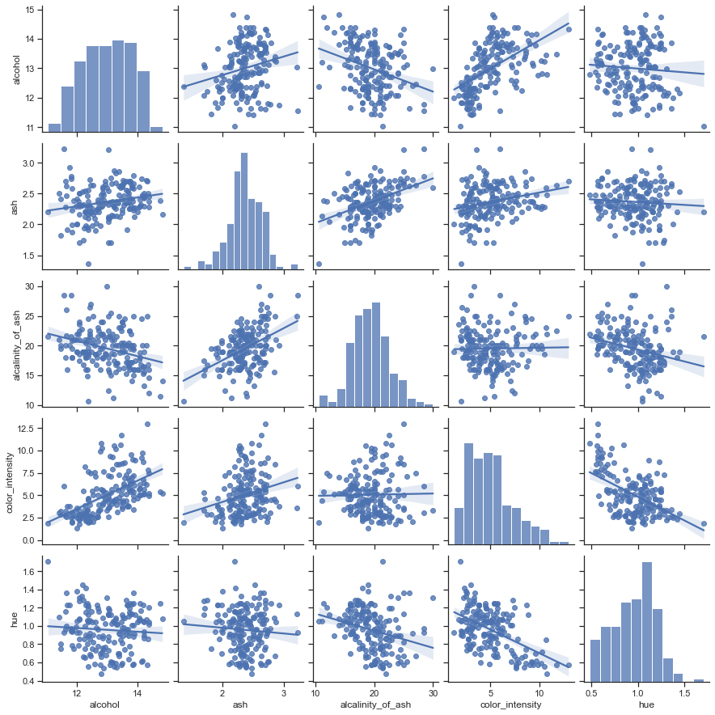

```python
## EJECUTAR ESTE BLOQUE

import matplotlib.pyplot as plt
import seaborn as sns; sns.set(style="ticks", color_codes=True)
import pandas as pd

wine = load_wine()
data = pd.DataFrame(data=wine['data'], columns=wine['feature_names'])

data['target'] = wine['target']
data['class'] = data['target'].map(lambda ind: wine['target_names'][ind])

g = sns.pairplot(data.iloc[:, [0,2,3,9,10]], kind="reg") # Parametro kind="reg" agrega una recta
plt.show()
```

# Parte 2: Entrenar/testear clasificadores

En esta parte useremos el clasificador **Decision Tree**. Veremos distintas formas de usarlo, y vamos a compararlas utilizando diversas métricas.

## CLASIFICADOR 1

## Pregunta 2.1

Usando el siguiente código, complete lo que falta para entrenar el clasificador con los datos cargados (X, y) y hacer una predicción sobre los mismos datos empleando dicho clasificador entrenado. Luego, muestre las métricas de **accuracy**, **precision**, **recall** y **f1-score**.

```python
## RESPUESTA PREGUNTA 2.1

from sklearn.tree import DecisionTreeClassifier
from sklearn.metrics import accuracy_score
from sklearn.metrics import classification_report

clf = DecisionTreeClassifier()

X = wine.data      ## datos, caracteristicas o features
y = wine.target    ## clase para cada instancia anterior

# .... COMPLETE ACA
```

```python
clf.fit(X, y)   ## Entrenar usando X (features), y (clase)

y_pred = clf.predict(X)   ## predecir 'y' usando la matriz 'X'
print(y_pred)
```

```
[0 0 0 0 0 0 0 0 0 0 0 0 0 0 0 0 0 0 0 0 0 0 0 0 0 0 0 0 0 0 0 0 0 0 0 0 0
 0 0 0 0 0 0 0 0 0 0 0 0 0 0 0 0 0 0 0 0 0 0 1 1 1 1 1 1 1 1 1 1 1 1 1 1 1
 1 1 1 1 1 1 1 1 1 1 1 1 1 1 1 1 1 1 1 1 1 1 1 1 1 1 1 1 1 1 1 1 1 1 1 1 1
 1 1 1 1 1 1 1 1 1 1 1 1 1 1 1 1 1 1 1 2 2 2 2 2 2 2 2 2 2 2 2 2 2 2 2 2 2
 2 2 2 2 2 2 2 2 2 2 2 2 2 2 2 2 2 2 2 2 2 2 2 2 2 2 2 2 2 2]
```

```python
# Evaluación de métricas accuracy, precision, recall, f1-score
print("Accuracy:", accuracy_score(y, y_pred))
print(classification_report(y, y_pred))
```

```
Accuracy: 1.0
              precision    recall  f1-score   support

           0       1.00      1.00      1.00        59
           1       1.00      1.00      1.00        71
           2       1.00      1.00      1.00        48

    accuracy                           1.00       178
   macro avg       1.00      1.00      1.00       178
weighted avg       1.00      1.00      1.00       178
```

## Pregunta 2.2

De acuerdo a las métricas obtenidas:

1. ¿Qué opina sobre las predicciones?
2. ¿Qué problema puede identificar?

Opinamos que las predicciones no son generalizables. La predicción es perfecta, no se equivoca nunca, porque no estamos generalizando el modelo. Sólo estamos prediciendo datos que ya entrenamos, por lo que el modelo ya los conoce. Estos resultados no son representativos de cómo rendiría el modelo con datos que no ha visto nunca. Lo que en verdad opinamos que hay que hacer es dividir los datos entre entrenamiento y testing, con tal de entrenar con los datos de entrenamiento y después intentar predecir los de testing, y luego evaluar.

## CLASIFICADOR 2

Ahora lo que haremos será dividir nuestro dataset en 70% entrenar (*training set*) y 30% para testear (*testing set*). Use la función *train_test_split()* de *sklearn* y utilice las variables `X_train, X_test, y_train, y_test`.

## Pregunta 2.3

Escriba el código necesario para dividir los datos, entrenar el modelo e indicar el **accuracy**, **precision** y **recall** del clasificador. Entrene usando el *training set* y pruebe sobre el *testing set*, en base a la división 70%-30%, respectivamente

**NOTA: para dividir el dataset use el parámetro `stratify=y`.**

```python
### Respuesta a pregunta 2.3
# ...
# Recuerde usar las variables X_train, X_test, y_train, y_test
from sklearn.model_selection import train_test_split

# Dividir los datos entre entrenamiento y testing
X_train, X_test, y_train, y_test = train_test_split(X, y, test_size=.30, random_state=37,
                                                    stratify=y)

clf.fit(X_train, y_train)   ## Entrenar usando X_train (features), y_train (clase)

y_pred = clf.predict(X_test)   ## predecir 'y' usando la matriz 'X'
print(y_pred)
```

```
[0 0 2 1 2 0 2 1 0 1 1 0 2 0 0 1 0 2 1 1 2 0 0 0 1 2 1 1 1 2 0 0 1 0 0 1 1
 1 0 2 1 2 2 0 1 1 1 2 0 2 1 2 1 0]
```

```python
# Evaluación de métricas accuracy, precision, recall, f1-score
print("Accuracy en test set:", accuracy_score(y_test, y_pred))
print(classification_report(y_test, y_pred))
```

```
Accuracy en test set: 0.9259259259259259
              precision    recall  f1-score   support

           0       0.89      0.94      0.92        18
           1       0.90      0.90      0.90        21
           2       1.00      0.93      0.97        15

    accuracy                           0.93        54
   macro avg       0.93      0.93      0.93        54
weighted avg       0.93      0.93      0.93        54
```

## Pregunta 2.4

Según el resultado obtenido en la pregunta anterior, responda lo siguiente:

1. ¿Cuál clasificador tiene peores resultados? ¿Por qué?
2. ¿Cuál de las dos formas de entrenar el clasificador prefiere? Justifique su respuesta
1. En términos de métricas los resultados del clasificador 1 son mejores, pero no son generalizables. Realemente, no sabemos cómo se comporta con datos desconocidos. Si bien las métricas del clasificador 1 son perfectas, las del clasificador 2 son mejores en el sentido que se evalúan en datos desconocidos y obitene arriba de 90% en casi todas las métricas.
2. Preferimos la segunda forma en entrenar el clasificador, porque de esta manera podemos saber cómo se comporta con datos desconocidos que es lo que realmente nos interesa, que sea generalizable.

## Pregunta 2.5

El siguiente código genera una matriz de confusión de los resultados de clasificación de la pregunta 2.4. Ejecute el bloque completo para visualizar el gráfico. Interprete la matriz y comente sobre cada uno de los valores distintos de 0 en la matriz y describa lo que representa. **Verifique que su respuesta concuerde con lo que se imprime en la matriz (ya que los resultados pueden variar ligeramente si vuelve a entrenar el modelo).**

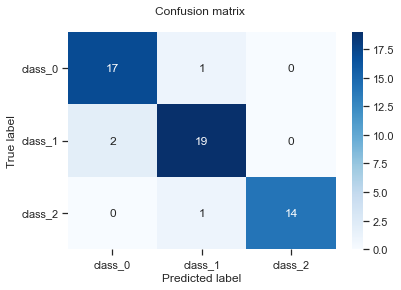

```python
## EJECUTAR ESTE BLOQUE

from sklearn.metrics import confusion_matrix
from sklearn.utils.multiclass import unique_labels

# Compute confusion matrix. By default is not normalized (normalize=None)
# If necessary change 'y_pred' according to your variable name
cm = confusion_matrix(y_test, y_pred)

# Only use the labels that appear in the data
classes = wine.target_names[unique_labels(y_test, y_pred)]

df = pd.DataFrame(cm, index = classes, columns = classes)

g = sns.heatmap(df, annot=True, cmap="Blues")
g.set_yticklabels(g.get_yticklabels(), rotation = 0)

plt.title('Confusion matrix \n')
plt.xlabel('Predicted label')
plt.ylabel('True label')

plt.autoscale()
```

La matriz de confusión nos indica cómo fueron predecidas las clases y cómo son realmente. Si vemos la primera fila, podemos ver que la clase 0 fue correctamente predicha en 17 instancias, pero una vez fue mal etiquetada y predicha como clase 1. En la segunda fila, podemos ver que la clase 1 fue erróneamente etiquetada como clase 0 dos veces, mientras que fue correctamente predicha 19 veces. En la tercera fila, la clase 2 fue incorrectamente etiquetada una vez como clase 1, mientras que fue correctamente predicha 14 veces. En total hay 4 instancias mal predichas y 50 correctas, de un total de 54.

## CLASIFICADOR 3

Para este clasificador utilizaremos Cross-validation. Con cross-validation, el conjunto de entrenamiento se divide en $k$ conjuntos disjuntos; se entrena sobre los datos correspondientes a $k-1$ de éstos, y se evalúa sobre el conjunto restante. Esto se repite $k$ veces, evaluando siempre sobre un conjunto distinto. Teniendo en cuenta el parámetro $k$, a éste método se le llama $k$-fold cross-validation.

El código que está a continuación realizará 10-fold cross-validation usando Decision Tree sobre los datos. La forma de estimar el rendimiento del clasificador es, entre otras cosas, calculando el promedio de todos los k-folds.

Además se muestra la predición sobre los datos para testear.

```python
## EJECUTAR ESTE BLOQUE

from sklearn.model_selection import cross_validate
import numpy as np

scoring = ['precision_macro', 'recall_macro', 'accuracy', 'f1_macro']
cv_results = cross_validate(clf, X, y, cv = 10, scoring = scoring, return_train_score= True)

print('Promedio Precision:', np.mean(cv_results['test_precision_macro']))
print('Promedio Recall:', np.mean(cv_results['test_recall_macro']))
print('Promedio F1-score:', np.mean(cv_results['test_f1_macro']))
print('Promedio Accucary:', np.mean(cv_results['test_accuracy']))

#Si quisieramos mostrar el resultado de cada k-fold, deberiamos quitar la
#funcion np.mean la cual retorna el promedio. Esto mostraría una lista con el resultado de cada fold
```

```
Promedio Precision: 0.8786111111111111
Promedio Recall: 0.8668253968253969
Promedio F1-score: 0.8590597365597367
Promedio Accucary: 0.8594771241830067
```

## Pregunta 3.1

- Compare los valores de las métricas con respecto a lo obtenido en la pregunta 2.4 y comente en qué difieren y por qué.
- ¿Qué beneficios tiene emplear cross-validation?

En el caso de DecisionTree de la pregunta 2, las métricas son más altas que cross-validation, esto se debe a que sólo se divide el dataset una vez y los datos de training siempre son sólo para entrenar y los de testing siempre son sólo para testear. Mientras que con cross validation todas las particiones se usan para training y testing. Esto quiere decir que de alguna manera, todos los datos fueron parte del entrenamiento y también en algún momento datos desconocidos para el modelo. Esto resulta en un modelo más general lo que tiende a bajar las métricas ya que como el dataset es pequeño le cuesta más predecir muchos datos desconocidos. Pero el clasificador de la pregunta 2 fue probado con menos datos en promedio, por lo que es más probable que tenga métricas más altas. Los beneficios de usar cross validation son que se entrena y se testea con todos los datos disponibles en el dataset, lo que aprovecha al máximo la cantidad de datos que tenemos sin aprenderse el dataset y disminuyendo el riesgo de overfitting